# In Exploratory Data Analysis what all things we do.

# Analyzing the impact of toss decisions on match outcomes

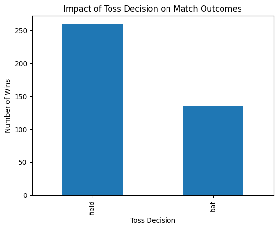

```python
# Analyzing the impact of toss decisions on match outcomes
toss_impact = df[df['toss_winner'] == df['winner']]
toss_decision_wins = toss_impact['toss_decision'].value_counts()

toss_decision_wins.plot(kind='bar', title='Impact of Toss Decision on Match Outcomes', xlabel='Toss Decision', ylabel='Number of Wins')
```

# Ovservation

1. The bar chart effectively illustrates the correlation between toss decisions and match outcomes.
2. It suggests that teams choosing to field after winning the toss have won more matches.

# Correlation Between Toss and Match Outcome

```python
df['toss_match_winner'] = df['toss_winner'] == df['winner']
toss_match_winner_percentage = df['toss_match_winner'].mean() * 100
toss_match_winner_percentage
```

```
51.98412698412699
```

# Observation:

Winning the toss appears to have a slight impact on the match outcome, with a success rate of 51.98%.

# Count the values in the 'city' column to determine where the most matches were played.

```python
df.city.value_counts()
```

```
city
Mumbai            101
Kolkata            77
Delhi              74
Bangalore          66
Hyderabad          64
Chennai            57
Jaipur             47
Chandigarh         46
Pune               38
Durban             15
Bengaluru          14
Visakhapatnam      13
Centurion          12
Ahmedabad          12
Rajkot             10
Mohali             10
Indore              9
Dharamsala          9
Johannesburg        8
Cuttack             7
Ranchi              7
Port Elizabeth      7
Cape Town           7
Abu Dhabi           7
Sharjah             6
Raipur              6
Kochi               5
Kanpur              4
Nagpur              3
Kimberley           3
East London         3
Bloemfontein        2
Name: count, dtype: int64
```

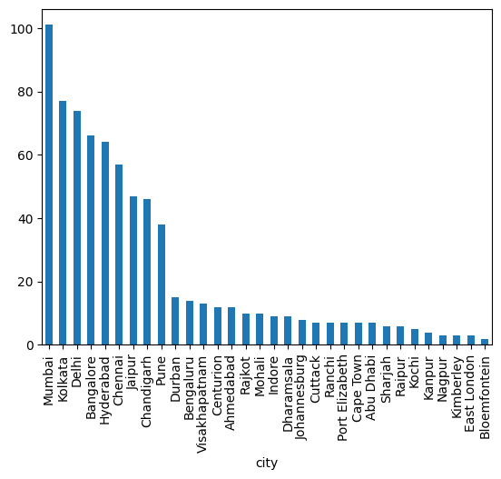

```python
df.city.value_counts().plot(kind='bar')
```

# Observation

Mumbai hosted the most matches (101), while several cities like Bloemfontein hosted only a few (2).

# Top cities and venues

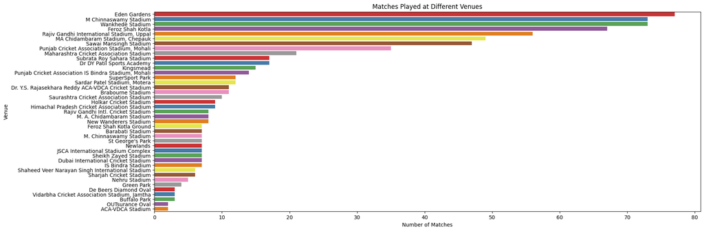

```python
plt.figure(figsize=(19,7))
venue_plot = sns.countplot(y='venue', data=df, order=df['venue'].value_counts().index, palette='Set1')
plt.title('Matches Played at Different Venues')
plt.xlabel('Number of Matches')
plt.ylabel('Venue')
plt.show()
```